# March 14, 2022

```python
import numpy as np
import matplotlib.pyplot as plt
```

```python
%matplotlib notebook
```

## Quick $\pi$-day experiment:

Consider a circle of radius $R$ circumscribed by a square of side lengths $2R$.

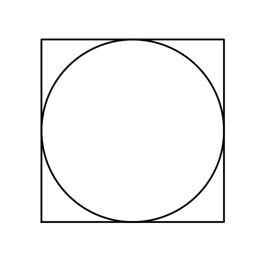

```python
from math import pi

R = 1                                          # Choose circle radius

plt.figure(figsize=(3,3))
t = np.linspace(0,2*pi,500)                    # Parametrize a circle
plt.plot(R*np.cos(t),R*np.sin(t),'k-')         # plot a circle of radius R
plt.plot([-R,R,R,-R,-R],[-R,-R,R,R,-R],'k-')   # plot the circumscribing square with side lengths 2R
plt.axis('equal')                              # Fix aspect ratio to be 1:1
plt.axis('off')                                # Remove all axis labels and ticks
plt.show()
```

The area of the square is $A_{\text{square}} = (2R) \cdot (2R) = 4R^2$. The area of the circle is $A_{\text{circle}} = \pi R^2$. Then the ratio between the areas is $$\frac{A_\text{circle}}{A_\text{square}} = \frac{\pi R^2}{4R^2} = \frac{\pi}{4}.$$ Solving for $\pi$ gives $$\pi = 4\cdot\frac{A_\text{circle}}{A_\text{square}}.$$

Without knowing $\pi$, we can approximate the ratio $\frac{A_\text{circle}}{A_\text{square}}$ by randomly selecting numerous coordinates $(x,y)$ with $-R \leq x,y \leq R$, then taking the ratio of the number of coordinates $(x,y)$ inside the circle (i.e. $x^2 + y^2 < R^2$) versus the total number of points selected.

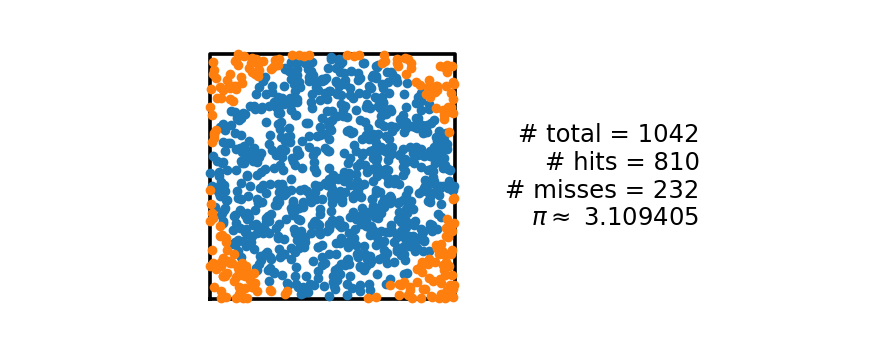

```python
from numpy.random import rand                 # Generate uniformly random points between [0,1]
from time import time                         # Get current time (in seconds from epoch)

T = 30                                        # Fix simulation time...
                                              # ...the code will continue generating random
                                              # points until 'T' seconds have elapsed

R2 = R**2                                     # Pre-compute square radius

fig = plt.figure(figsize=(5,2))               # Generate figure
ax = plt.subplot(1,1,1)                       # Generate axes

ax.plot([-R,R,R,-R,-R],[-R,-R,R,R,-R],'k-')   # Plot circumscribing square with side lengths 2R
ax.set_xlim(-1.1*R,3*R)                       # Set x-limits of plot
ax.set_aspect('equal',adjustable='box')       # Fix aspect ratio to be 1:1
ax.axis('off')                                # Remove all axis labels and ticks

num_total = 0                                 # Total number of random points selected

num_hits = 0                                  # Count the number of points inside the circle
x_hits = []                                   # x-coordinates of each point inside the circle
y_hits = []                                   # y-coordinates of each points inside the circle

num_misses = 0                                # Count the number of points outside the circle
x_misses = []                                 # x-coordinates of each point outside the circle
y_misses = []                                 # y-coordinates of each point outside the circle

hits_plot, = ax.plot([],[],'C0.')             # Initialize plot of points inside the circle
misses_plot, = ax.plot([],[],'C1.')           # Initialize plot of points outside the circle

start_time = time()                           # Start timer
current_time = time()                         # Initialize current time

status_str = '# total = {:}\n'                # Build string template that will keep track...
status_str += '# hits = {:}\n'                # ...of the counts and approximation within...
status_str += '# misses = {:}\n'              # ...the figure
status_str += '$\pi \\approx$ {:7.6f}'

status_text = ax.text(1,.5,'',                # Initialize status text at position (1,.5)...
                      transform=ax.transAxes, # using axes coordinates...
                      ha='right',va='center') # ...with given horizontal and vertical text alignment

while current_time - start_time < T:          # Continue until 'T' seconds have elapsed
    current_time = time()                     # Update current time
    x,y = R*(2*rand(2) - 1)                   # Get new random coordinates
    num_total += 1                            # Increment total number of points selected

    r2 = x**2 + y**2                          # Compute distance from origin of new coordinates
    if r2 < R2:                               # Check if (x,y) is inside the circle
        num_hits += 1                         # Increment number of points inside circle
        x_hits.append(x)                      # Update x-coordinates of points inside circle
        y_hits.append(y)                      # Update y-coordinates of points inside circle
        hits_plot.set_data(x_hits,y_hits)     # Update plot with new points inside circle

    else:                                     # Otherwise, point is outside circle
        num_misses += 1                       # Increment number of points outside circle
        x_misses.append(x)                    # Update x-coordinates of points outside circle
        y_misses.append(y)                    # Update y-coordinates of points outside circle
        misses_plot.set_data(x_misses,y_misses) # Update plot with new points outside circle

    pi_approx = 4*num_hits/num_total          # Update approximation of pi

    status_text.set_text(status_str.format(num_total,  # Update status text
                                           num_hits,
                                           num_misses,
                                           pi_approx))

    fig.canvas.flush_events()                 # Required to force pyplot to update text
    fig.canvas.draw()                         # Force pyplot to update the figure
```

```python
for n in np.arange(1,9):
    N = 10**n
    x,y = R*(2*np.random.rand(2,N) - 1)
    r2 = x**2 + y**2

    num_hits = (r2 < R2).sum()
    num_total = len(r2)
    pi_approx = 4*num_hits/num_total

    print('N = 10^{}: pi ~= {:7.6f}'.format(n,pi_approx))
```

```
N = 10^1: pi ~= 3.600000
N = 10^2: pi ~= 2.960000
N = 10^3: pi ~= 3.188000
N = 10^4: pi ~= 3.130800
N = 10^5: pi ~= 3.139760
N = 10^6: pi ~= 3.141572
N = 10^7: pi ~= 3.141723
N = 10^8: pi ~= 3.141660
```

## More plotting with matplotlib.pyplot

```python
import numpy as np
import matplotlib.pyplot as plt
```

```python
%matplotlib inline
```

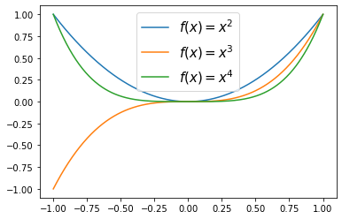

```python
x = np.linspace(-1,1,500)

plt.plot(x,x**2,label='$f(x) = x^2$')
plt.plot(x,x**3,label='$f(x) = x^3$')
plt.plot(x,x**4,label='$f(x) = x^4$')

plt.legend(loc='upper center',fontsize=15)

plt.show()
```

```python
help(plt.legend)
```

[output not shown]

[output cut: 207 more lines]

[output not shown]

## Specifying colors in matplotlib

### Color maps

```python
import matplotlib.cm as cm
```

```python
dir(cm)
```

[output not shown]

[output cut: 138 more lines]

[output not shown]

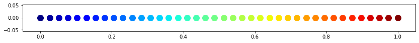

```python
x = np.linspace(0,1,40)

plt.figure(figsize=(14,1))

for t in x:
    plt.plot(t,0,'o',markersize=12,color=cm.jet(t))
```

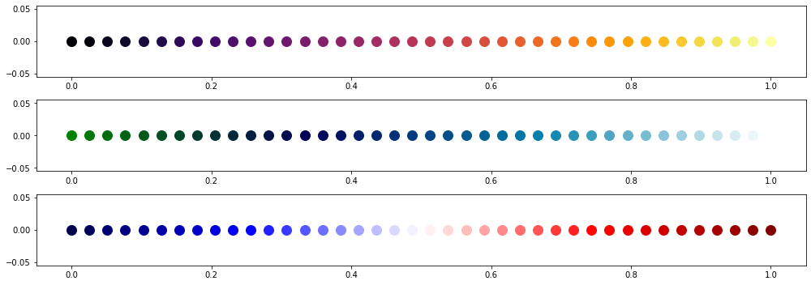

```python
plt.figure(figsize=(14,5))

plt.subplot(3,1,1)
for t in x:
    plt.plot(t,0,'o',ms=12, color=cm.inferno(t))

plt.subplot(3,1,2)
for t in x:
    plt.plot(t,0,'o',ms=12, color=cm.ocean(t))

plt.subplot(3,1,3)
for t in x:
    plt.plot(t,0,'o',ms=12, color=cm.seismic(t))

plt.tight_layout()
plt.show()
```

This gives us one method of selecting colors beyond the default `'b'`,`'r'`,`'k'`,`'y'`, etc.

We've seen how to add subplots using the `plt.subplot` command, and we've seen how to store the output for later use. For example, if we define `ax = plt.subplot(1,1,1)`, this gives an axis object. We use a number of methods attached to that axis object.

We can directly plot to this subplot using the `ax.plot` method.

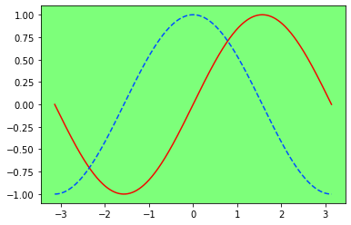

```python
x = np.linspace(-np.pi,np.pi,1000)

plt.figure()
ax = plt.subplot(1,1,1)

ax.plot(x,np.sin(x),'-', color=cm.jet(.9))
ax.plot(x,np.cos(x),'--', color=cm.jet(.2))

ax.set_facecolor(cm.jet(.5))

plt.show()
```

```python
dir(ax)
```

[output not shown]

[output cut: 400 more lines]

[output not shown]

What does a colormap actually return?

```python
cm.jet(.5)
```

```
(0.4901960784313725, 1.0, 0.4775458570524984, 1.0)
```

What do these numbers mean? This 4-tuple is an RGBA number:

- R is the red value
- G is the green value
- B is the blue value
- A is the alpha or transparency value

## RGB colors

The RGB color model uses basic colors red, green, and blue. All other colors are obtained as mixtures of these basic colors. In the RGB model each color is specified by three numbers describing the intensities of red, blue and green. In `matplotlib` these intensities are normalized to lie between `0` (full off) and `1` (full on).

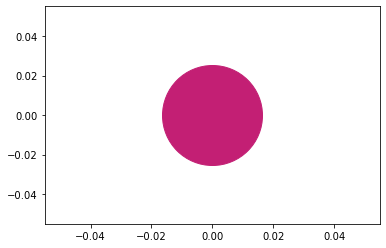

```python
plt.plot(0,0,'o',ms=100, color=(.765,.123,.456))
```

Let's try to get a sense of what the RGB color space looks like.

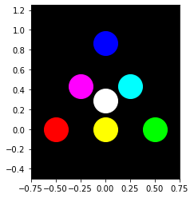

```python
plt.figure()
ax = plt.subplot(1,1,1)
ax.set_facecolor((0,0,0))

ax.set_ylim(-.5,1.25)
ax.set_xlim(-.75,.75)
ax.set_aspect('equal')

h = (3**.5)/2

ax.plot(-.5,0,'o',ms=30,color=(1,0,0))
ax.plot(.5,0,'o',ms=30,color=(0,1,0))
ax.plot(0,h,'o',ms=30,color=(0,0,1))

ax.plot(0,0,'o',ms=30,color=(1,1,0))
ax.plot(-.25,h/2,'o',ms=30,color=(1,0,1))
ax.plot(.25,h/2,'o',ms=30,color=(0,1,1))

ax.plot(0,h/3,'o',ms=30,color=(1,1,1))

plt.show()
```

## Multidimensional arrays

```python
a = np.arange(20)

print(a)
```

```
[ 0  1  2  3  4  5  6  7  8  9 10 11 12 13 14 15 16 17 18 19]
```

One method of generating multidimensional arrays is by using the `np.reshape` function:

```python
b = a.reshape(4,5)

print(b)
```

```
[[ 0  1  2  3  4]
 [ 5  6  7  8  9]
 [10 11 12 13 14]
 [15 16 17 18 19]]
```

`a.reshape(4,5)` generates a 2-dimensional array that has 4 rows and 5 columns. Note: $4\times 5 = 20$, so we're able to reshape the original length array 20 array in this way.

```python
a.reshape(4,2)
```

```
---------------------------------------------------------------------------
ValueError                                Traceback (most recent call last)
<ipython-input-37-ac55fe697c9f> in <module>
----> 1 a.reshape(4,2)

ValueError: cannot reshape array of size 20 into shape (4,2)
```

```python
print(b.shape)
```

```
(4, 5)
```

```python
print(b.reshape(20))
```

```
[ 0  1  2  3  4  5  6  7  8  9 10 11 12 13 14 15 16 17 18 19]
```

```python
c = a.reshape(10,2)

print(c)
```

```
[[ 0  1]
 [ 2  3]
 [ 4  5]
 [ 6  7]
 [ 8  9]
 [10 11]
 [12 13]
 [14 15]
 [16 17]
 [18 19]]
```

```python
print(c.shape)
```

```
(10, 2)
```

We can also reshape into 3-dimensions:

```python
d = a.reshape(5,2,2)
print(d.shape)
```

```
(5, 2, 2)
```

Note: A reshaped array is a view of the original array. Changes to the reshaped array will apply to the original array as well.

```python
print(a)
print()
print(b)
```

```
[ 0  1  2  3  4  5  6  7  8  9 10 11 12 13 14 15 16 17 18 19]

[[ 0  1  2  3  4]
 [ 5  6  7  8  9]
 [10 11 12 13 14]
 [15 16 17 18 19]]
```

To access elements of a 2-d array, we use indexing just like with 1-d arrays: `b[i,j]` accesses the element in the `i`th row and `j`th column.

```python
a[3]
```

```
3
```

```python
b[2,3]
```

```
13
```

```python
b[2,3] = -5

print(a)
print()
print(b)
```

```
[ 0  1  2  3  4  5  6  7  8  9 10 11 12 -5 14 15 16 17 18 19]

[[ 0  1  2  3  4]
 [ 5  6  7  8  9]
 [10 11 12 -5 14]
 [15 16 17 18 19]]
```

```python
e = b.copy()

e[2,3] = 100

print(a)
print()
print(e)
```

```
[ 0  1  2  3  4  5  6  7  8  9 10 11 12 -5 14 15 16 17 18 19]

[[  0   1   2   3   4]
 [  5   6   7   8   9]
 [ 10  11  12 100  14]
 [ 15  16  17  18  19]]
```

We can also use slicing to access parts of a 2-d array.

```python
print(a[2:-1:2])
```

```
[ 2  4  6  8 10 12 14 16 18]
```

We can access the `0`th column of `b` using `b[:,0]`

```python
print(b[1:,0])
```

```
[ 5 10 15]
```

```python
print(b[1,::2])
```

```
[5 7 9]
```

```python
print(b[1:,:-1])
```

```
[[ 5  6  7  8]
 [10 11 12 -5]
 [15 16 17 18]]
```

### Other methods for generating multi-dimensional arrays

We can convert a list of lists into a multi-dimensional array:

```python
triples = np.array([[1,2,3],
                    [4,5,6],
                    [7,8,9],
                    [10,11,12]])
```

```python
print(triples)
```

```
[[ 1  2  3]
 [ 4  5  6]
 [ 7  8  9]
 [10 11 12]]
```

```python
a = triples[:,0]
b = triples[:,1]
c = triples[:,2]
```

```python
print(b)
```

```
[ 2  5  8 11]
```

Note: the interior lists must all have the same length.

```python
np.array([[1,2,3],
          [4,5,6],
          [7,8]])
```

```
array([list([1, 2, 3]), list([4, 5, 6]), list([7, 8])], dtype=object)
```

The `np.zeros` function and `np.ones` function can also generate multi-dimensional arrays.

```python
a = np.ones(5)
print(a)
```

```
[1. 1. 1. 1. 1.]
```

Instead of supplying a single integer, we give a tuple `(i,j)` to generate an array of shape `(i,j)`.

```python
b = np.ones((5,3))

print(b)
```

```
[[1. 1. 1.]
 [1. 1. 1.]
 [1. 1. 1.]
 [1. 1. 1.]
 [1. 1. 1.]]
```

```python
c = np.zeros((3,6))

print(c)
```

```
[[0. 0. 0. 0. 0. 0.]
 [0. 0. 0. 0. 0. 0.]
 [0. 0. 0. 0. 0. 0.]]
```

```python
print(3*b - 1)
```

```
[[2. 2. 2.]
 [2. 2. 2.]
 [2. 2. 2.]
 [2. 2. 2.]
 [2. 2. 2.]]
```

```python
np.sin(3*b-1)
```

```
array([[0.90929743, 0.90929743, 0.90929743],
       [0.90929743, 0.90929743, 0.90929743],
       [0.90929743, 0.90929743, 0.90929743],
       [0.90929743, 0.90929743, 0.90929743],
       [0.90929743, 0.90929743, 0.90929743]])
```

```python
4**b
```

```
array([[4., 4., 4.],
       [4., 4., 4.],
       [4., 4., 4.],
       [4., 4., 4.],
       [4., 4., 4.]])
```

```python
a = np.array([[1,2],
              [3,4]])
b = np.array([[5,6],
              [7,8]])

print(a*b)
```

```
[[ 5 12]
 [21 32]]
```

In the above cell, we generated two $2 \times 2$ arrays. Multiplying them computes the element-by-element product. What if we want to compute the matrix product of the $2 \times 2$ matrices?

# March 16, 2022

```python
import numpy as np
import matplotlib.pyplot as plt
```

```python
a = np.array([[1,2],
              [3,4]])
b = np.array([[5,6],
              [7,8]])

print(a*b)
```

```
[[ 5 12]
 [21 32]]
```

If we want to compute the matrix product, we can use the `.dot` method:

```python
print(a.dot(b))   # Matrix product a * b
```

```
[[19 22]
 [43 50]]
```

```python
print(b.dot(a))   # Matrix product b * a
```

```
[[23 34]
 [31 46]]
```

## Visualizing 2D arrays using the `imshow` function.

The `np.random.rand()` function produces a numpy array of a given shape containing random floats between $0$ and $1$.

```python
a = np.random.rand(3,3)    # This generates a 3 x 3 numpy array with random values betweeen 0 and 1
```

```python
print(a)
```

```
[[0.88325797 0.13268413 0.40474575]
 [0.8524122  0.93926139 0.62875341]
 [0.97987839 0.04681831 0.24408545]]
```

The `matplotlib` function `imshow()` creates an image from a 2d array. This image will have one square for every entry in the array. The color of each square is determined by the corresponding value of the array element in that entry, along with the selected colormap.

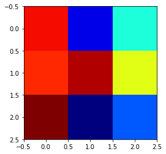

```python
plt.imshow(a,cmap='jet')
```

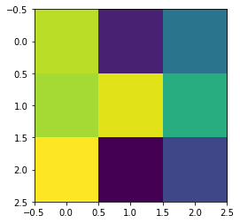

```python
plt.imshow(a,cmap='viridis')
```

```python
help(plt.imshow)
```

[output not shown]

[output cut: 138 more lines]

[output not shown]

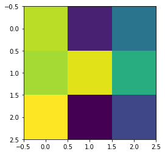

```python
plt.imshow(a,cmap='viridis',interpolation='nearest')
```

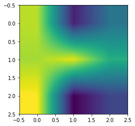

```python
plt.imshow(a,cmap='viridis',interpolation='bilinear')
```

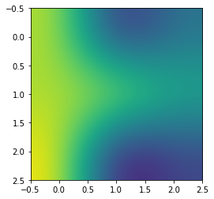

```python
plt.imshow(a,cmap='viridis',interpolation='bicubic')
```

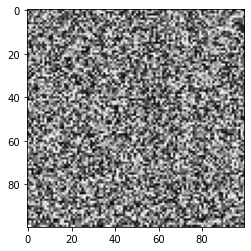

```python
a = np.random.rand(100,100)
plt.imshow(a,cmap='gray')
```

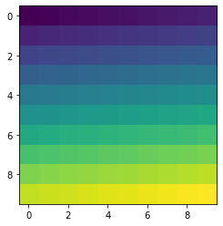

```python
a = np.arange(100).reshape(10,10)

plt.imshow(a)
```

```python
print(a)
```

```
[[ 0  1  2  3  4  5  6  7  8  9]
 [10 11 12 13 14 15 16 17 18 19]
 [20 21 22 23 24 25 26 27 28 29]
 [30 31 32 33 34 35 36 37 38 39]
 [40 41 42 43 44 45 46 47 48 49]
 [50 51 52 53 54 55 56 57 58 59]
 [60 61 62 63 64 65 66 67 68 69]
 [70 71 72 73 74 75 76 77 78 79]
 [80 81 82 83 84 85 86 87 88 89]
 [90 91 92 93 94 95 96 97 98 99]]
```

The `vmax` and `vmin` optional arguments can be set to specify the lowest and largest to be colorized. In other words, any value in the array smaller than `vmin` will be colored the same as `vmin`, and value larger than `vmax` will be colored the same as `vmax`.

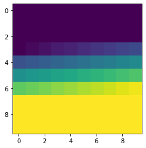

```python
a = np.arange(100).reshape(10,10)

plt.imshow(a,vmin=30,vmax=70)
```

## imshow with RGB

The `imshow` function also works with a 3D array where the third dimension has length 3, and contains RGB values (normalized between 0 and 1).

```python
a = np.random.rand(10,10,3)
```

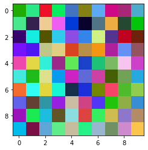

```python
plt.imshow(a)
```

```python
a[0,2]
```

```
array([0.93828944, 0.06630991, 0.16652185])
```

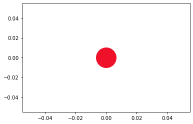

```python
plt.plot(0,0,'o',ms=40,color=a[0,2])
```

## Tartans

```python
N = 40                   # Size of the imshow grid

a = np.empty((N,N,3))
b = np.empty((N,N,3))
print(a.shape)
```

```
(40, 40, 3)
```

```python
M = 4                    # Number of colors

colors = np.random.rand(M,3)

for i in range(M):
    a[N//M*i:N//M*(i+1),:] = colors[i]

for j in range(M):
    b[:,N//M*j:N//M*(j+1)] = colors[j]
```

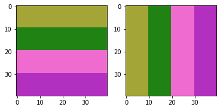

```python
plt.figure()

plt.subplot(1,2,1)
plt.imshow(a)

plt.subplot(1,2,2)
plt.imshow(b)
```

**Exercise.** Create a checkerboard pattern that combines the arrays `a` and `b` and plot using `imshow`.

The `np.empty_like()` can be used to generate an empty array with the same properties (shape, data type, etc) of a given array.

```python
c = np.empty_like(a)
```

```python
# Let's iterate through every row and column of 'c', and choose the color as appropriate from 'a' or 'b'.
for i in range(c.shape[0]):
    for j in range(c.shape[1]):
        if ...:
            c[i,j] = a[i,j]
        else:
            c[i,j] = b[i,j]
```

We can export the plot from `imshow` using the `imsave` command.

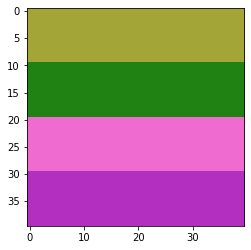

```python
plt.imshow(a)
```

```python
plt.imsave('a.png',a)
```

Note: The RGB values for the Tartan project are normalized between 0 and 255. You will need to rescale them to lie between 0 and 1 for `imshow` to work.

Pattern: B14 K6 B6 K6 B6 K32

```python
B = np.array([52,80,100])/256
K = np.array([16,16,16])/256
```

```python
colors = [B,K,B,K,B,K]
widths = [14,6,6,6,6,32]

N = sum(widths)

vert = np.empty((N,N,3))

j = 0
for color,width in zip(colors,widths):
    vert[:,j:j+width] = color
    j = j+width
```

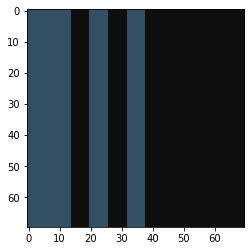

```python
plt.imshow(vert)
```